# Plot Annual Participation Networks

Preparation for network analysis in CCIEA ESR

M. Fisher, J.F. Samhouri

Written Jan. 6, 2021. Last Run 2021-03-01

# Description

Plot annual fisheries participation networks (from igraph object) by port group, crab year.

Section 2 will generate network graphs that are colored according to the gear group used in each fishery. You have the option to use either the force-directed layout algorithm developed by [Fruchterman & Reingold (1991)](http://citeseerx.ist.psu.edu/viewdoc/download?doi=10.1.1.13.8444&rep=rep1&type=pdf) or a simple circular layout. The Fruchterman & Reingold layout is informative but can result in overlap / odd clustering, especially if there is a fishery that has no / weakly connecting edges to other fisheries in the network.

Section 3 will generate simplified network graphs using a circular layout that highlight the Dungeness crab node (the visualizations used for Figure 1 in Fisher et al. 2021, PNAS). The plotting function in this section of the script could be adjusted to more flexibly highlight other fisheries.

This script requires the following packages.

```r
if(!require("tidyverse")) {install.packages("tidyverse")}
if(!require("ggplot2")) {install.packages("ggplot2")}
if(!require("igraph")) {install.packages("igraph")}
if(!require("RColorBrewer")) {install.packages("RColorBrewer")}
if(!require("stringr")) {install.packages("stringr")}
```

And calls the following functions:

```r
source(here::here('R/color_network_nodes.R'))
source(here::here('R/plot_network.R'))
source(here::here('R/plot_simple_network.R'))
```

# User Inputs

Select your directories.

```r
## location of igraph objects
indir = 'data/networks/participation'

## output directory for network viz
pngdir = 'data/networks/participation/plots'
```

Identify the crab years and port groups that you would like to produce networks for.

```r
## (crab) years
years <- seq(2004,2019)
# years <- 2008 # testing script, 1/6
# years <- 2018 # testing script, 1/8
# years <- 2014 # testing script, 1/27

## port groups
myports <- c("Puget Sound","North WA Coast","WA Coast","Other Coastal Washington","Astoria","Tillamook","Columbia River","Newport","Coos Bay","Brookings","Crescent City","Eureka","Morro Bay","Fort Bragg","Bodega Bay","San Francisco","San Diego","Monterey","Santa Barbara","Los Angeles","Unknown Ports" )
#myports <- c("BDG") # testing script, 1/6
#myports <- c("Columbia River") # testing script for single node networks, 1/7
# myports <- c("Monterey") # testing script, 1/8
# myports <- c("Bodega Bay") # testing script, 1/27/21
```

Do you want to plot using the Fruchterman & Reingold layout [“fr”], a circular layout [“c”], or both [“both”]?

```r
my_layout <- "both"
```

# 1: Read in data

Read the igraph objects into a list. This for loop will also apply the functions to recolor and rename vertices

```r
#palette(brewer.pal(n = 10, name = "Set3"))
#pal3 <- brewer.pal(n = 10, name = "Set3")

graphs_list <- list()
graph_names <- c()
i=1
for(p in myports){
  for(y in years){
  #y=2013 # testing script for single node networks, 1/7
  # y=2014 # testing script for single node networks, 1/27
    if(file.exists(here::here(indir, paste0("igraph_", p, "_", y ,"_rmCrab.rds")))){
      tmpgraph <- readRDS(here::here(indir, paste0("igraph_", p, "_", y ,"_rmCrab.rds")))
      V(tmpgraph)$p <- p
      V(tmpgraph)$year <- y
      V(tmpgraph)$colors <- vertex_color(tmpgraph)
      graphs_list[[i]] <- tmpgraph
      graph_names[i] <- paste0(p,"_",y)
      i = i + 1
      } else{ y = y +1 }
  }
}
names(graphs_list) <- graph_names
```

# 2: Plot with Color-Adjusted Nodes

Plots will be written out to .png files in the function. This is because the igraph `plot` function won’t save into an object that can be returned.

```r
lapply(graphs_list,plot_network, my_layout, outdir=pngdir)
```

[output not shown]

[output cut: 934 more lines]

[output not shown]

An example of the F-R layout:

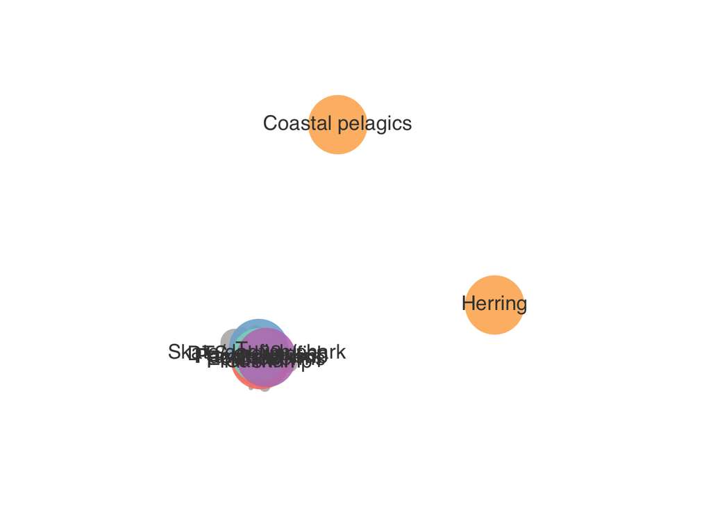

An example of the circular layout:

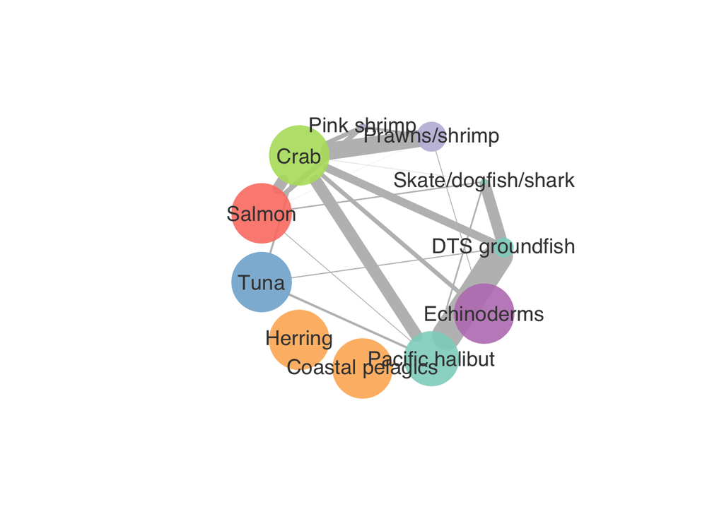

# 3: Simple Plot

Plots will be written out to .png files in the function. This is because the igraph `plot` function won’t save into an object that can be returned.

```r
lapply(graphs_list,plot_simple, outdir=pngdir)
```

[output not shown]

[output cut: 934 more lines]

[output not shown]

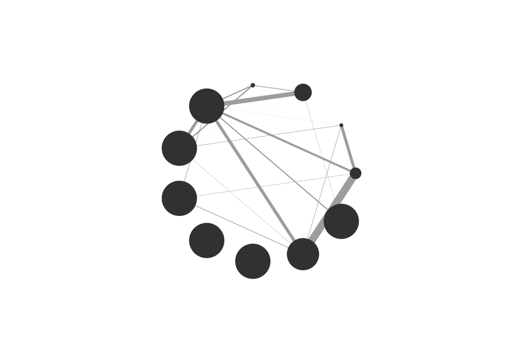

Put the 2019 and all Newport circular graphs in their own directories

```r
list.of.files_2019 <- list.files(here::here(pngdir), "2019_circular_cciea")
file.copy(here::here(pngdir,list.of.files_2019), here::here(pngdir, "2019 only"), overwrite = TRUE)
```

```
##  [1] TRUE TRUE TRUE TRUE TRUE TRUE TRUE TRUE TRUE TRUE TRUE TRUE TRUE TRUE TRUE
## [16] TRUE TRUE TRUE TRUE TRUE
```

```r
list.of.files_newport <- intersect(list.files(here::here(pngdir), pattern = "Newport"), list.files(here::here(pngdir), pattern = "circular"))
file.copy(here::here(pngdir,list.of.files_newport), here::here(pngdir, "newport"), overwrite = TRUE)
```

```
##  [1] TRUE TRUE TRUE TRUE TRUE TRUE TRUE TRUE TRUE TRUE TRUE TRUE TRUE TRUE TRUE
## [16] TRUE
```